# Lab06

Channing_503128649

20/09/2021

# Import

1. Produce a tidier file automobile.csv

```r
o <- read.csv("automobile-original.csv", na.strings = "?")
o <- na.omit(o)
o <- subset(o, select = -c(engine.location))
write.csv(o, "automobile.csv", row.names = FALSE)

d1 <- read.csv("automobile.csv")
d2 <- read.csv("automobile-subset.csv")
all(d1 == d2)
```

```
## [1] TRUE
```

# Explore

2. Write R code to answer the following questions:

What is the mean price (price) of all vehicles?

```r
mean(d1$price)
```

```
## [1] 11445.73
```

How many vehicles have 4 doors (num.of.doors)?

```r
nrow(d1[d1$num.of.doors == "four",])
```

```
## [1] 95
```

What are the different engine types (engine.type) among the observations?

```r
unique(d1$engine.type)
```

```
## [1] "ohc"  "l"    "dohc" "ohcv" "ohcf"
```

How many vehicles have a price (price) higher than $20000?

```r
nrow(d1[d1$price > 20000,])
```

```
## [1] 13
```

What is the mean price (price) for “4wd” (drive.wheels)?

```r
mean(d1[d1$drive.wheels == "4wd",]$price)
```

```
## [1] 10241
```

3. Produce pairwise scatterplots between variables normalized.losses, wheel.base, peak.rpm and price

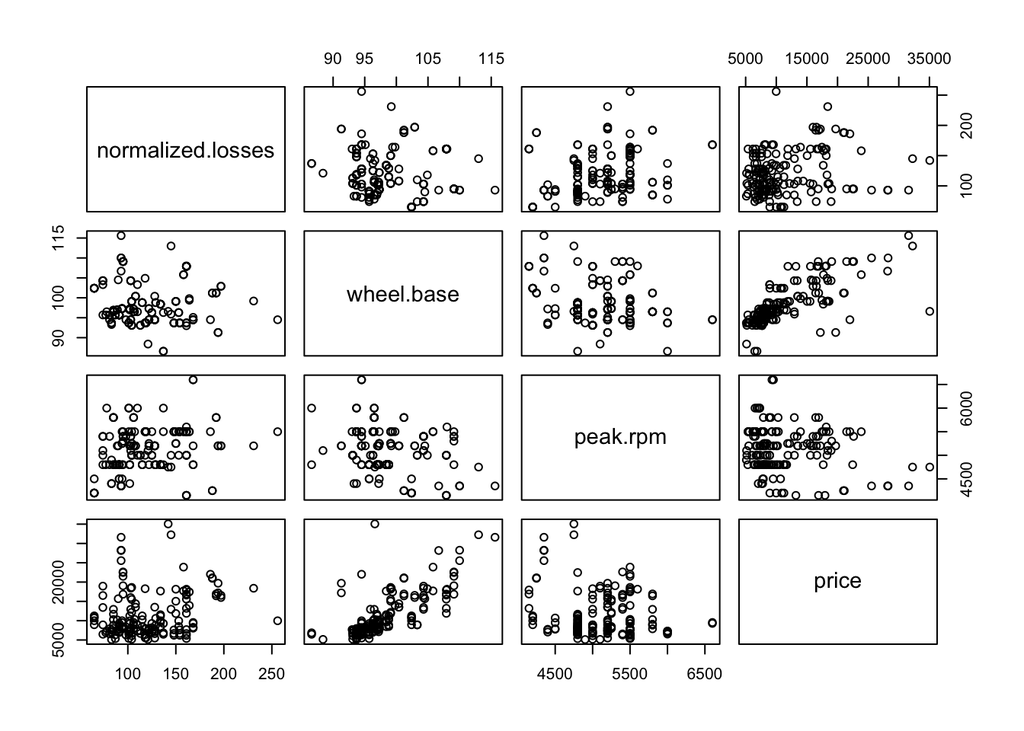

```r
pairs(~normalized.losses + wheel.base + peak.rpm +price, data=d1)
```

# Linear regression

For all of the following regression questions, we use the price (price) as the response variable.

4. Produce the full linear regression model with all variables included. Comment on the outcome.

```r
fit <- lm(price~., d1)
summary(fit)
```

```
##
## Call:
## lm(formula = price ~ ., data = d1)
##
## Residuals:
##     Min      1Q  Median      3Q     Max
## -2949.8  -587.9     0.0   650.3  2259.2
##
## Coefficients: (3 not defined because of singularities)
##                         Estimate Std. Error t value Pr(>|t|)
## (Intercept)            2.309e+04  1.560e+04   1.480 0.141731
## symboling             -5.068e+00  2.163e+02  -0.023 0.981351
## normalized.losses      5.577e+00  6.252e+00   0.892 0.374295
## makebmw                3.596e+02  1.791e+03   0.201 0.841251
## makechevrolet         -4.745e+03  1.856e+03  -2.556 0.011985 *
## makedodge             -6.209e+03  1.613e+03  -3.851 0.000201 ***
## makehonda             -1.583e+03  1.739e+03  -0.910 0.364854
## makejaguar             2.431e+03  2.918e+03   0.833 0.406615
## makemazda             -4.063e+03  1.568e+03  -2.591 0.010906 *
## makemercedes-benz      2.548e+03  1.608e+03   1.584 0.116050
## makemitsubishi        -6.328e+03  1.578e+03  -4.010 0.000113 ***
## makenissan            -3.690e+03  1.470e+03  -2.510 0.013557 *
## makepeugot            -5.143e+03  4.732e+03  -1.087 0.279561
## makeplymouth          -6.025e+03  1.618e+03  -3.723 0.000316 ***
## makeporsche            4.830e+03  2.091e+03   2.310 0.022810 *
## makesaab              -4.040e+02  1.552e+03  -0.260 0.795107
## makesubaru            -7.317e+03  2.301e+03  -3.180 0.001927 **
## maketoyota            -5.869e+03  1.594e+03  -3.682 0.000364 ***
## makevolkswagen        -4.297e+03  1.355e+03  -3.170 0.001986 **
## makevolvo             -2.871e+03  1.838e+03  -1.563 0.121105
## fuel.typegas          -1.065e+04  5.139e+03  -2.072 0.040708 *
## aspirationturbo        2.171e+03  5.956e+02   3.646 0.000413 ***
## num.of.doorstwo       -8.381e+02  3.795e+02  -2.208 0.029366 *
## body.stylehardtop     -5.627e+03  1.375e+03  -4.091 8.33e-05 ***
## body.stylehatchback   -5.736e+03  1.343e+03  -4.271 4.23e-05 ***
## body.stylesedan       -5.702e+03  1.398e+03  -4.080 8.71e-05 ***
## body.stylewagon       -5.647e+03  1.414e+03  -3.995 0.000119 ***
## drive.wheelsfwd       -2.936e+01  6.501e+02  -0.045 0.964064
## drive.wheelsrwd        1.977e+03  9.553e+02   2.070 0.040895 *
## wheel.base             3.184e+02  8.310e+01   3.832 0.000215 ***
```

[output cut: 16 more lines]

```
## fuel.systemmpfi        2.602e+03  1.081e+03   2.407 0.017808 *
## fuel.systemspdi        1.081e+03  1.292e+03   0.837 0.404621
## bore                  -8.817e+02  1.427e+03  -0.618 0.538041
## stroke                -5.677e+02  9.524e+02  -0.596 0.552409
## compression.ratio     -7.000e+02  3.844e+02  -1.821 0.071380 .
## horsepower            -2.019e+01  1.911e+01  -1.057 0.292973
## peak.rpm              -5.377e-01  5.658e-01  -0.950 0.344070
## city.mpg              -1.564e+02  1.030e+02  -1.518 0.131872
## highway.mpg            1.284e+02  8.912e+01   1.441 0.152517
## ---
## Signif. codes:  0 '***' 0.001 '**' 0.01 '*' 0.05 '.' 0.1 ' ' 1
##
## Residual standard error: 1165 on 107 degrees of freedom
## Multiple R-squared:  0.9734, Adjusted R-squared:  0.9607
## F-statistic: 76.78 on 51 and 107 DF,  p-value: < 2.2e-16
```

There are too many variables in this linear model, where some of variables are significant but could be highly correlated. Also, 3 coeffiences are not available.

5. Remove any variable(s) that seem to cause the linear regression to fail, i.e., some coefficients may become NA. Repeat this until you can produce a meaningful “full” linear regression model (it is okay if you remove slightly more variables than necessary).

How many variables are deemed to be significant by the t-tests (with a p-value less than 0.05)?

```r
fit <- lm(price ~ . - fuel.system - num.of.cylinders - engine.type, d1)
coef <- summary(fit)$coefficients
table(coef[,4]<0.05)
```

```
##
## FALSE  TRUE
##    18    24
```

There’re 24 significant variables.

6. Apply your “full” linear regression model to the data and compute the resulting mean squared error (MSE).

```r
mse = function(y1, y2) mean( (y1 - y2)^2 )
mse(predict(fit, d1), d1$price)
```

```
## [1] 1107500
```

# Subset selection

```r
library(leaps)
library(glmnet)
```

7. For the data (using your “full” set of variables), produce a subset linear regression model, using the backward selection and the AIC.

```r
r.bwd = regsubsets(price ~ . - fuel.system - num.of.cylinders - engine.type, nvmax = 38, data=d1, method="backward")
r.s <- summary(r.bwd)
bic <- r.s$bic
aic <- bic - (log(nrow(d1)) - 2) * (38:1)
j = which.min(aic)
beta = coef(r.bwd, j)
beta
```

```
##         (Intercept)       makechevrolet           makedodge           makehonda
##         17908.63085         -5980.10911         -7615.82056         -5505.11491
##           makemazda      makemitsubishi          makenissan          makepeugot
##         -4507.70019         -8073.20659         -4907.11451         -8360.61669
##        makeplymouth          makesubaru          maketoyota      makevolkswagen
##         -7520.61552         -6636.69665         -6798.15202         -5215.54416
##           makevolvo     aspirationturbo   body.stylehardtop body.stylehatchback
##         -4490.72017          1625.24581         -7088.22297         -6209.99436
##     body.stylesedan     body.stylewagon     drive.wheelsrwd          wheel.base
##         -5516.20648         -5293.49476          1471.33885           380.48283
##              length              height         curb.weight
##          -138.78747          -519.48153             7.50285
```

8. Apply the AIC-selected model to the data and compute the resulting MSE.

```r
d1.matrix <- model.matrix(fit)
yhat = drop(d1.matrix[,names(beta)] %*% beta)
mse(yhat, d1$price)
```

```
## [1] 1434429
```

# LASSO

10. For the data (using your “full” set of variables), compute the Lasso model.

```r
x <- d1.matrix[,-1]
y <- d1$price
r.lasso = glmnet(x, y, alpha=1)
```

11. Create a coefficient profile plot of the coefficient paths that varies with the value of λ (or log(λ)).

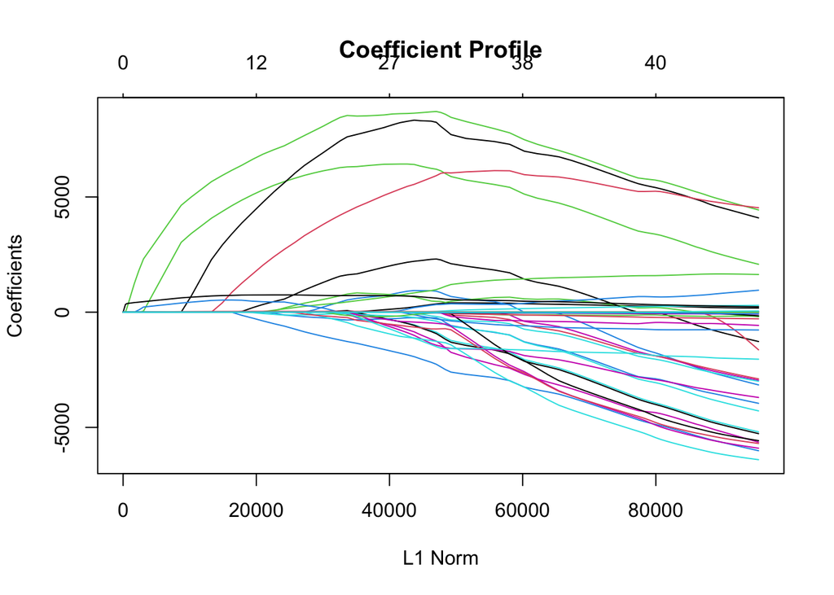

```r
plot(r.lasso, main="Coefficient Profile")
```

# Summary

In this lab, we went though the data science process with a focus on the model with lots of variable. We used two main techniques to choose the best submodel, model selection criteria and regularisation.

There’re 2 main criteria, namely, AIC and BIC, they based the maximum likelihood with the only different on the penalty terms. AIC tends to preserve the variables while BIC penalise heavily on the numbers of variables with the growth of observations.

The regularisation approaches shrink the coefficients instead. To that, Lasso can do it more efficient by shrinking the coefficients to exactly 0.